# Week 6 Short Answer Questions

## Mira Ensley-Field

Compiled on Thu Mar 23 09:03:55 2017.

# Chapter 12

12.1 : for each sex find the 5 most popular babyNames adding up over all the years

This was used for testing purposes

```r
BabyNames_small<-sample(BabyNames,10000,replace=FALSE)
```

```r
Popular<-
  BabyNames %>%
  group_by(name,sex) %>%
  summarise(total=sum(count)) %>%
  mutate(the_rank=rank(desc(total))) %>%
  arrange(-total)
```

Top 5 Male Names - James - John - Robert - Michael - William

Top 5 Female Names - Mary - Elizabeth - Patricia - Jennifer - Linda

# 12.2

I was able to create the first part of the data table (Below) and I created a graphic with that

```r
PopularCounts<-
  BabyNames_small %>%
  group_by(year)  %>%
  summarise(total=sum(count)) %>%
  mutate(frac_in_top_100=(total/2))

PopularCounts[1:10,]
```

```
## # A tibble: 10 × 3
##     year total frac_in_top_100
##    <int> <int>           <dbl>
## 1   1880   195            97.5
## 2   1881   800           400.0
## 3   1882   494           247.0
## 4   1883  1954           977.0
## 5   1884  1891           945.5
## 6   1885   735           367.5
## 7   1886   204           102.0
## 8   1887   387           193.5
## 9   1888  1801           900.5
## 10  1889   654           327.0
```

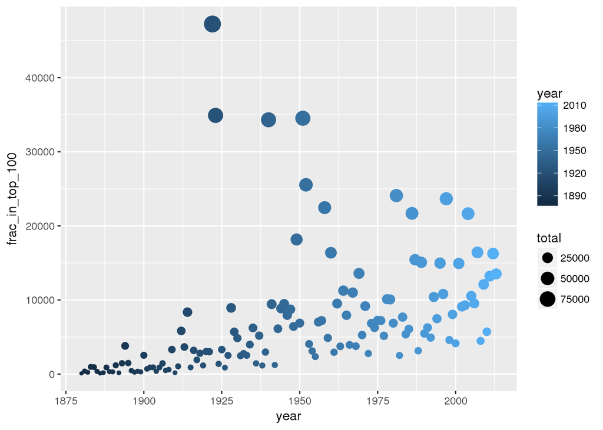

```r
ggplot(data=PopularCounts, aes(x=year, y =frac_in_top_100)) + geom_point(aes(x=year, y =frac_in_top_100,size=total,col=year))
```

The code egiven in the book doesn’t seem to work..I tried a few variations but unfortunately I couldn’t get their mutate function to work correctly. I tried to fix the format by gathering (the commented out section, but I couldn’t get it to work)

```r
glyph<-
  PopularCounts %>%
  spread(frac_in_top_100,total) %>%
  mutate(frac_in_top_100 = TRUE / (TRUE + FALSE)) # %>%
  #gather(key=count,value=-year )

glyph[1:10,]
```

[output not shown]

# 12.3

a.) transformation verb: rank

b.) transformation verb: rank

c.) summary function: nrow

d.) summary function: nrow (if leap year, then fewer cases)

e.) neither

f.) summary function: range

g.) neither…probably use lucidate package

h.) summary function

# 13.1

1. There are 8 distinct vertices
2. there are 9 edges

# 13.2

1. The certices are the letters A,B,C, and D
2. Table 2 shows them correcly
3. Table 1 has incorrect edges…B and C aren’t connected and Table 3 is a completey incorrect configuration

# 13.3

Table 2

# 13.4

1. the size of the letter is mapped to exports
2. pop is mapped to the shape of the gray symbol